# AI for Economic Research

Using agents and learning with AI

Dr David Chivers

PhD Economics Workshop

## Our path through the workshop

1. **Understand** progress and how LLMs work
2. **Learn** with questions, hints and experiments
3. **Try** one paper, one agent and one skill
4. **Adapt** the method to your PhD

Leave able to **produce something useful, check it and reuse the method**.

## 1. Introduction to LLMs

Progress, training, hallucinations and alignment.

## AI is moving quickly

Will Smith eating spaghetti, generated by AI.

**March 2023**

[video not shown]

The face, fork and spaghetti keep changing shape.

**February 2026**

[video not shown]

A much steadier scene, face and eating action.

Public posting dates. Selected examples, not a controlled comparison. Internet required. [2023 source](https://www.reddit.com/r/StableDiffusion/comments/1244h2c/will_smith_eating_spaghetti/) · [2026 source](https://www.reddit.com/r/singularity/comments/1r1auy1/will_smith_eating_spaghetti_by_seedance_20_is/)

## AI can complete longer tasks

METR estimates the human task duration at which an AI agent succeeds **half the time**.

[figure not shown]

[METR data and methods](https://metr.org/time-horizons/). TH1.1 results through May 2026; saved data checked against METR on 15 October 2026. Software tasks, not an economics productivity measure.

## Predicting text can produce useful reasoning

A **large language model (LLM)** uses a neural network to predict the next **token** from the available context.

Thecatsatonthe?

| Next token | Probability |
| --- | --- |
| mat | 0.50 |
| sofa | 0.30 |
| All others | 0.20 |

**Tokens** are words, word-parts or punctuation; the split varies by model.

**Attention** draws on instructions, earlier messages and supplied material.

Choose a token; extend the context; repeat. This can generate a reasoned answer.

Next-token probability is not the probability that a claim is true.

Invented probabilities and simplified token boxes. [Vaswani et al. (2017)](https://arxiv.org/abs/1706.03762) · [Brown et al. (2020)](https://arxiv.org/abs/2005.14165).

## Training is an optimisation problem

In a simplified pretraining setup, choose the parameters to make observed text more likely:

$$\hat\theta \approx \underset{\theta}{\operatorname{arg\,min}}\;
-\sum_{x\in\mathcal D}\sum_{t=1}^{T_x}
\log p_\theta(x_t\mid x_1,\ldots,x_{t-1})$$

- $\theta$: the network’s parameters; $\mathcal D$: training texts; $x_t$: token $t$.
- **Maximum likelihood**, on a very large scale. Gradient-based updates reduce the loss.
- Training is limited by data and compute. Fitting the data does not guarantee true answers.

**Training changes the weights. Inference uses them.** In a normal chat, your prompt changes the context; the model’s weights usually stay fixed.

Stylised next-token pretraining objective; [Brown et al. (2020)](https://arxiv.org/abs/2005.14165). Modern training includes further stages.

## Training an assistant: which reply is better?

**Pretraining** learns to predict text. **Post-training** shapes how the model responds.

**Reply A · agrees with the user**

“Yes. Your pay rise gives you more purchasing power.”

**Reply B · checks the claim**

“Your pay buys about **2.8% less**: $1.05/1.08-1\approx-0.028$.”

**Training feedback: prefer B to A.** Many such comparisons are used during training to adjust the model’s parameters towards higher-rated replies.

**Alignment:** train the model to help accurately, including correcting the user.

Invented prompt and replies illustrating preference-based training. [Ouyang et al. (2022)](https://arxiv.org/abs/2203.02155).

## Why might AI guess?

A **hallucination** is a plausible answer containing false or unsupported claims. Knowledge gaps and reasoning errors matter; incentives can also favour guessing.

**Show the maths**

Suppose the AI **believes it is 90% likely to be right**. Assume **risk neutrality over points**, no other costs, **correct: +1** and **“I don’t know”: 0**.

| Score for a mistake | Expected score from answering | Best response |
| --- | --- | --- |
| 0 | $0.9(1)+0.1(0)=0.9$ | Answer |
| −1 | $0.9(1)+0.1(-1)=0.8$ | Answer |
| −20 | $0.9(1)+0.1(-20)=-1.1$ | Abstain |

For believed probability $p$ and loss $L\geq0$, answer if $p-(1-p)L>0$, or $p>\frac{L}{1+L}$.

### Reward correct answers

**Correct: +1. Wrong: 0.**  
**“I don’t know”: 0.**

Guessing offers a chance of a point; abstaining guarantees zero.

### Penalise wrong answers

A large penalty makes abstaining more attractive.

**Fewer errors, but more unanswered questions.** It does not fill knowledge gaps.

Another option: **check a source, ask for clarification or explain what remains uncertain.**

Toy scoring rules; beliefs may be wrong. Real LLMs need not calculate these scores. [Why language models hallucinate (2025)](https://openai.com/index/why-language-models-hallucinate/).

## A citation is the start of a check

| Check | What you need to establish |
| --- | --- |
| **Source** | Open the original paper and check its identity. |
| **Claim** | Find the passage or result that supports the sentence. |
| **Scope** | Check the population and outcome: assisted performance, an unaided test, or retention? |

Ask for the supporting passage and limitations. **Read them yourself.** A second chatbot can repeat the error.

A real source does not guarantee a justified interpretation.

## 2. Learning with AI

Use the assistant to build your understanding.

## Better answers and deeper learning

Research develops your ability to **explain, apply and judge ideas**. AI can improve the work in front of you while leaving those abilities unchanged.

### Performance with assistance

Can you produce a convincing explanation, correct calculation or polished piece of writing while the assistant is available?

This can be useful. It measures the combined output.

### Learning you can use

Can you explain the mechanism, spot a faulty assumption and solve a different problem without the assistant?

This is what you need to carry into the next task.

Decide which part of the thinking you are trying to learn before asking AI to do it.

## Learn by experimenting

**Income and substitution effects:** the price of X falls from £2 to £1.

1. **Predict.** What happens to purchases of X and Y? Make a prediction first.
2. **Explore.** Open the diagram ↗, then select **Price change → Substitution → Income**.
3. **Explain.** Which effect reflects relative prices? Which reflects purchasing power?

This example uses Cobb–Douglas preferences and Hicksian compensation. Actual income stays at £12 and the price of Y at £1.

**Optional: ask AI to build your own**

“Build an interactive diagram for [topic], using the model in my notes. Let me change one input, predict the result and reveal the explanation.”

Check the result against your course material. Later: working with files and tools.

## Use AI to help you understand

**Getting a good answer is not the same as learning.**

- Outsourcing the reasoning can weaken learning.
- Guided tutoring can help: ask for questions, hints and feedback.

> I can follow a difference-in-differences calculation, but I struggle to explain why parallel trends matters. Help me reason it through. Ask one question and wait for my attempt; give hints before revealing the answer.

Different settings and mixed results; this prompt is an illustration, not a tested intervention. [Bastani et al. (2025)](https://doi.org/10.1073/pnas.2422633122) · [Kestin et al. (2025)](https://www.nature.com/articles/s41598-025-97652-6) · [Shen & Tamkin (2026 preprint)](https://arxiv.org/abs/2601.20245).

## 3. Using AI

Agents, context, verification and a task of your own.

## Just ask the AI.

- How do I do this?
- What should I try next?
- Why can’t you do this?
- I don’t understand.
- Explain what you did.
- Make it simpler.
- What am I missing?
- Can you show an example?

For current information, ask it to **look it up and research it**.

Its training data may be out of date.

## From chatting to doing

### The chatbot workflow

“Write a discussion note from my reading notes.”

The AI gives you an answer in the chatbox.

**You copy, paste, format and save it.**

### The agentic workflow

“Make a discussion note from my checked notes and save the files here.”

The AI uses tools to create and edit the files.

**You open the result, check it and ask for changes.**

**Agentic working** means the AI can carry out steps in a task. Writing and running code is one example.

You still guide the work and judge the result.

## What you will build

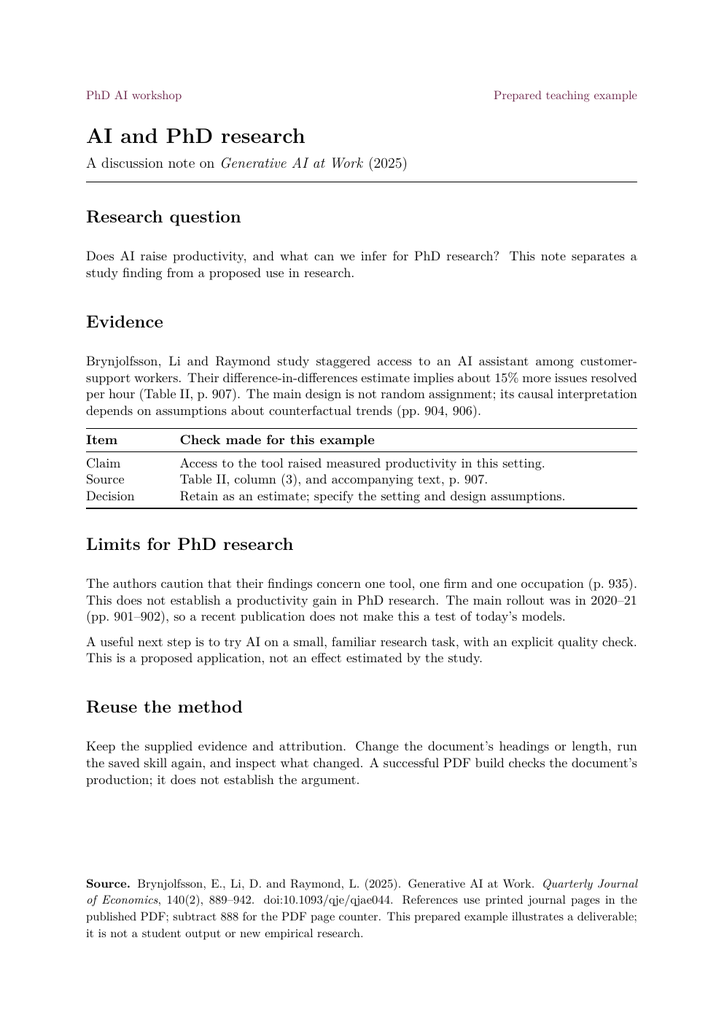

### A useful research output

- A short note on the shared paper.
- Evidence you have checked yourself.
- A reviewer role and a reusable LaTeX skill.
- A project you can pick up again.

Example PDF · Editable LaTeX

**Develop a request. Check the result. Save what works.**

Prepared teaching example, discussing Brynjolfsson, Li and Raymond (2025). Your note and judgments will be your own.

## Your project folder is on your computer

```
ai-workshop/
  README.md
  papers/
  inputs/
  notes/
  outputs/
  .github/
```

The README can explain:

- What question you are working on.
- Where the permitted inputs live.
- Which paper or proposal to read.
- What is settled and what comes next.

`.github/` is a local folder for Copilot’s setup files. **No GitHub upload is needed.**

## One paper, three useful outputs

Use *Generative AI at Work*, published in the **Quarterly Journal of Economics (2025)**.

The paper estimates **15% more issues resolved per hour, on average**, after access to an AI assistant at one customer-support firm.

1. A reading note with a claim you have checked.
2. A reviewer comment you can accept, qualify or reject.
3. A LaTeX discussion note made with your own saved skill.

[Open the paper](https://danielle.li/assets/docs/GenerativeAIatWork.pdf) Download the example folder

The folder includes the **paper PDF and Durham Quarto skill**. Brynjolfsson, Li and Raymond (2025): customer-support workers at one firm. Exercise guide gives the selected pages and steps.

## Memory: save where you got to

Save a project note, then ask the AI to **read it in a new chat**.

**1. In this chat — save the plan**

> Add to README.md: we are focusing on how the paper identifies the effect. Next, check the parallel-trends assumption. Keep the existing guide.

**2. Start a new chat — pick up the plan**

> Read README.md. Remind me what we are focusing on, and help me take the next step.

Example plan, not a finding about the paper. The file persists; the new chat needs to read it. More on compaction.

## An agent, a skill and project memory

These are saved instructions and information you can inspect and change.

| What | What it saves | In this workshop |
| --- | --- | --- |
| **Agent** | A role, instructions and permitted tools | Critical reviewer: read and challenge |
| **Skill** | A reusable method for a recurring task | Economics notes → LaTeX |
| **Memory** | Project decisions and open questions | `README.md` |
| **Preferences** | How you want the assistant to work | “Use UK English. Explain edits.” |

A reviewer role is not automatically a different model or an independent expert.

VS Code: instructions, [custom agents](https://code.visualstudio.com/docs/agent-customization/custom-agents), skills.

## One request, several specialist subagents

You ask: **“Check my paper before I send it to my supervisor.”**

[figure not shown]

A subagent gets **its own brief and context** from the main agent. Findings return to your main conversation; **you decide what to change**.

Today we use just the Critical reviewer. Broader workflow illustrated; architecture: [Anthropic’s multi-agent research system](https://www.anthropic.com/engineering/multi-agent-research-system).

## 2. Make a Critical reviewer

**Design a reviewer for a question you care about.**

- Choose a focus: identification, measurement, theory assumptions or generalisation.
- Ask the main Agent to help create and save the reviewer.
- Inspect its instructions: **read the evidence, challenge the argument, leave the original unchanged**.

The role is saved for reuse. It is not automatically a different model or an independent expert.

Exercise guide has the setup steps. Example agent if needed.

## Make Durham slides from scratch

**Beamer:** LaTeX → PDF slides. **Quarto:** Markdown + LaTeX maths → browser slides.

**Start with an idea, notes or an outline. The skill includes the Durham design and logo.**

> Use examples/durham-quarto-slides/SKILL.md to make a short Quarto presentation about [my topic] for [my audience]. Help me shape the content, then render and open the slides.

[My Quarto guide and Durham skill](https://davidchivers.co.uk/slides/) Download the example folder

Optional extension: [install the Quarto application before class](https://quarto.org/docs/get-started/). The skill and VS Code extension do not install it. Only a browser is needed to view the finished slides.

## Adapt this to your research

**Use the same approach with your own paper, proposal or project.** Talk through what to keep and what to change with the AI.

- **Reviewer:** “Use my PhD proposal. Focus on the identification strategy.”
- **Document skill:** “Use my headings and writing style. Keep the qualifications.”
- **Memory:** “Save what we decided and what I should do next.”

Ask it to explain the change. Try it on a small example and check the result.

When models change, retest your skills; keep useful constraints and remove unnecessary detail. Exercise guide · [Skill design guidance](https://platform.claude.com/docs/en/agents-and-tools/agent-skills/best-practices).

## AI slop: fluent writing, weak substance

**Don’t paste a long chat answer straight into your paper.** Unedited output can bring vague claims, repetition and unsupported conclusions.

### Sounds impressive

“This groundbreaking study demonstrates the transformative potential of generative AI, unlocking unprecedented productivity gains and revolutionising academic research.”

**Which task? What changed? What supports the leap to research?**

### Gives the reader something

“AI assistance raised issues resolved per hour by about 15% among customer-support workers at one firm (Brynjolfsson et al., 2025). This does not establish gains in PhD research.”

**A specific result, its setting and a limit.**

[Pangram](https://www.pangram.com/) can flag likely AI-generated writing. **It does not judge the quality of your argument.**

Constructed examples, not detector results. [Brynjolfsson, Li and Raymond (2025)](https://danielle.li/assets/docs/GenerativeAIatWork.pdf), PDF pp. 19 and 47. Detector evidence and limits.

## What will you use it for this week?

- **Use it:** automate routine work and talk through research questions.
- **Save it:** keep useful preferences, project decisions and reusable methods.
- **Check it:** verify the evidence and your own understanding.

**An open question:** how much should you learn yourself when AI can do the work—for example, coding?

There is no single answer. Be deliberate about what you delegate and what you want to understand.

## Reference slides

**The workshop ends here. Use these links if a question comes up.**

- **Working with agents:** memory and compaction, clear responsibilities, model choice and costs, getting unstuck.
- **Writing:** Pangram and the limits of detection.
- **Practical materials:** paper, exercise folder and instructions.
- **Sources:** AI progress and tools, learning, LLMs and training.

## Compaction makes longer work possible

### Earlier advice

Long chats could lose important details. People often restarted with a hand-written summary.

### Current practice

Some agent systems compact earlier context automatically and continue the task. They can also revisit saved files.

Compaction can still omit details, especially in a complicated project.

### A useful habit

Keep the **current question, decisions, file locations and unresolved checks** in a short project note. Ask the agent to reread it when its work drifts.

[OpenAI compaction](https://developers.openai.com/api/docs/guides/compaction) and [Anthropic context engineering](https://www.anthropic.com/engineering/effective-context-engineering-for-ai-agents).

## One clear job per agent

**A clear job can contain several steps.** It needs a coherent objective and a result you can review.

| Clear responsibility | Harder to supervise |
| --- | --- |
| Check these five references and return the supporting passages | Improve my literature review, code and presentation |
| Clean this dataset and report merge failures | Fix everything in this folder |
| Reproduce this figure and explain discrepancies | Work on my PhD |

Keep one place where the overall research decisions are made.

## Match the model to the job

**Copilot Student uses Auto.** Where model choice is available:

### Lower-cost models

- Extract specified fields with page references.
- Format checked notes or references.

### More advanced models

- Assess identification assumptions.
- Resolve conflicting evidence.

> Keep costs down. If supported, use lower-cost subagents for routine work and a more advanced model for difficult reasoning. Check their results and tell me which models actually ran.

**More agents do not necessarily mean lower cost.** Include checking and rework.

Model choice depends on your tool and plan. [Copilot plans](https://docs.github.com/en/copilot/get-started/plans) · [Subagents and model selection](https://code.visualstudio.com/docs/agents/run/subagents). Checked 9 October 2026.

## When the assistant gets stuck

- Give the actual error or show the incorrect result.
- Ask it to identify the cause before changing more files.
- Reduce the problem to a small example you can inspect.
- Return to a verified checkpoint if the changes become confused.
- Restart with a short handover when the objective has changed or the context is misleading.

A fresh session is one option. It need not be the automatic response to every long conversation.

## Pangram: what does a detector tell you?

[Pangram](https://www.pangram.com/) estimates whether prose is **human-written, AI-assisted or AI-generated**.

- **Detection can work well.** Jabarian and Imas (2025) found very low false-positive and false-negative rates for Pangram in their test samples.
- **Errors still occur.** Pangram’s current guidance is for at least 50 words of prose; code and maths-heavy text are poor test cases.
- **Writing quality is a separate question.** A score does not establish accuracy, originality or the strength of your economics.

Use a detection result as evidence to consider, not a verdict on authorship or misconduct.

[Independent study: Jabarian and Imas](https://bfi.uchicago.edu/working-papers/artificial-writing-and-automated-detection/) · [Pangram 4: scope and limitations](https://www.pangram.com/research/model-card/pangram-4). Checked 5 October 2026.

## Sources: progress and agent workflows

- **METR.** [Task-Completion Time Horizons of Frontier AI Models](https://metr.org/time-horizons/). TH1.1 data, page updated 8 May 2026. [Raw data](https://metr.org/assets/benchmark_results_1_1.yaml).
- **METR (2026).** [Impact of modeling assumptions on time horizon results](https://metr.org/notes/2026-03-20-impact-of-modelling-assumptions-on-time-horizon-results/).
- **OpenAI.** [Compaction](https://developers.openai.com/api/docs/guides/compaction). Product documentation, accessed 2 October 2026.
- **Anthropic (2025).** [Effective context engineering for AI agents](https://www.anthropic.com/engineering/effective-context-engineering-for-ai-agents).
- **Anthropic (2026).** [Patterns and problems in emerging multiagent systems](https://www.anthropic.com/research/multiagent-systems), 13 August.

## Sources: economics and learning

- **Bastani et al. (2025).** [Generative AI without guardrails can harm learning](https://doi.org/10.1073/pnas.2422633122). PNAS, 122(26), e2422633122. [Author-hosted paper](https://hamsabastani.github.io/education_llm.pdf).
- **Kestin et al. (2025).** [AI tutoring outperforms in-class active learning](https://www.nature.com/articles/s41598-025-97652-6). Scientific Reports, 15, 17458.
- **Shen and Tamkin (2026).** [How AI Impacts Skill Formation](https://arxiv.org/abs/2601.20245). Preprint. [Authors’ explanation and group means](https://www.anthropic.com/research/AI-assistance-coding-skills).

## Exercise files and guidance

- **Shared paper:** Brynjolfsson, Li and Raymond (2025), [Generative AI at Work](https://doi.org/10.1093/qje/qjae044), *QJE* 140(2), 889–942. [Published PDF on the author’s site](https://danielle.li/assets/docs/GenerativeAIatWork.pdf).
- **Exercise folder:** download the ZIP. Includes the published paper PDF, setup instructions, fallback definitions and the full Durham Quarto skill.
- **Exercise guide:** download the guide. Three activities, detailed steps and optional extensions.
- **Critical reviewer:** download the agent file; [VS Code agent documentation](https://code.visualstudio.com/docs/agent-customization/custom-agents).
- **economics-to-latex:** download SKILL.md; [VS Code skill documentation](https://code.visualstudio.com/docs/agent-customization/agent-skills).
- **Setup:** [AI installation guide](https://davidchivers.co.uk/ai_install/). Exercise instructions revised 8 October 2026; account features may change.

## Sources: LLMs, training and alignment

- **Vaswani et al. (2017).** [Attention Is All You Need](https://arxiv.org/abs/1706.03762). The transformer architecture.
- **Brown et al. (2020).** [Language Models are Few-Shot Learners](https://arxiv.org/abs/2005.14165). Autoregressive pretraining and learning from examples in context.
- **Ouyang et al. (2022).** [Training language models to follow instructions with human feedback](https://arxiv.org/abs/2203.02155). Instruction tuning and RLHF.
- **Guo et al. (2025).** [DeepSeek-R1 incentivizes reasoning in LLMs through reinforcement learning](https://doi.org/10.1038/s41586-025-09422-z). Nature, 645, 633–638.
- **OpenAI (2025).** [Why language models hallucinate](https://openai.com/index/why-language-models-hallucinate/). Research explanation and linked paper, 5 September.